# DOE VPI+ - Birth Year Report

## SUMMARY OF DATA ELEMENT

| Year |
| --- |
| 2010 |
| 2011 |
| 2012 |

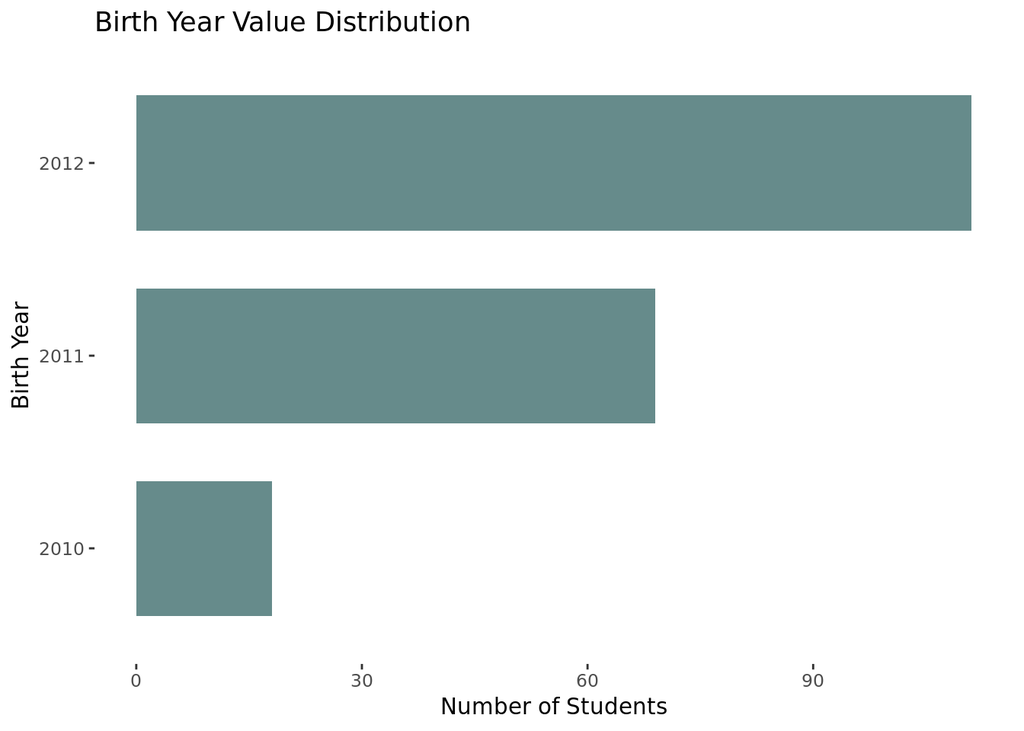

## DATA ANALYTICS SUMMARY OF RESULTS

| Test | Measurement Values | Value |
| --- | --- | --- |
| Completeness | Number of missing values | 0 |
|  | Percent of complete values | 100 % |
| Validity | Number of invalid values | 0 |
|  | Percent of valid values | 100 % |
| Uniqueness | Number of unique values | 3 |
| Record Consistency I | Number of inconsistent records | 0 |
|  | Percent consistent records | 100 % |
| Record Consistency II | Number of inconsistent records | 0 |
|  | Percent consistent records | 100 % |
| Longitudinal Inconsistency I | Individuals with inconsistent records | 0 |
|  | Percent individuals with consistent records | 100 % |

## UNIQUENESS

### A frequency distribution of values for Birth Year .

A basic Birth Year distribution plot is shown giving the frequency of the values 2010, 2011, 2012 occuring in the dataset.  
**Number of unique values 3**

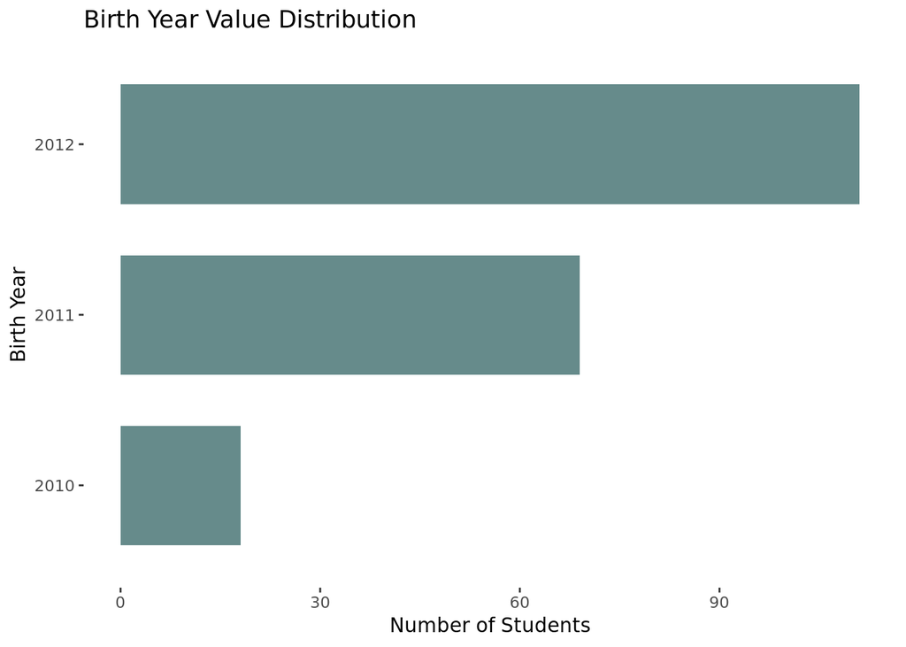

```r
values <-  cust_by_yr[!is_blank(birth_year), birth_year]

unique_values <-
  length(unique(values))

# frequency distribution table of active_status values
frequencies <- as.data.table(table(values))

# frequency distribution plot of active_status values
ggplot(frequencies, aes(values, N)) +
  geom_bar(stat = "identity", fill ="paleturquoise4", width=.7) +
  coord_flip() +ggtitle(paste(column_name_print, "Value Distribution")) +
  xlab("Birth Year") +
  ylab("Number of Students") +
  theme(panel.background=element_blank())
```

```r
# frequencies <- frequencies %>% dplyr::group_by(Freq) %>% dplyr::summarise(n = n())
```

```r
# sample of frequencies
print(head(frequencies))
```

```
##    values   N
## 1:   2010  18
## 2:   2011  69
## 3:   2012 111
```

## COMPLETENESS

### Find records with missing values for Birth Year .

The completeness of the data simply refers to whether or not there are missing or NULL values. Whether or not the values should be missing or null is genrally determined when assessing record consistency. In the case of Birth Year there should be no missing values.  
**Number Missing 0**  
**Percent Complete 100 %**

```r
missing <- cust_by_yr[is_blank(birth_year), .N]

print(missing)
```

```
## [1] 0
```

```r
#give the total count of responses
print(total_record_count, row.names = FALSE)
```

```
## [1] 198
```

```r
#calculate the percent of the variable which is complete
percent_complete <-
  truncate(((total_record_count - missing)/total_record_count)*100, prec = 2)

print(percent_complete, row.names = FALSE)
```

```
## [1] 100
```

## VALUE VALIDITY

### Find records with invalid values for Birth Year .

```r
invalid = cust_by_yr[is_blank(birth_year)|!birth_year %in% as.character(c(2010:2019)), .N]

# get number of rows with invlaid values for active_status
print(invalid)
```

```
## [1] 0
```

```r
# give the total count of responses
print(total_record_count, row.names = FALSE)
```

```
## [1] 198
```

```r
# calculate the percent of the variable which is valid
percent_valid = truncate(((total_record_count - invalid)/total_record_count)*100, prec = 2)
print(percent_valid, row.names = FALSE)
```

```
## [1] 100
```

```r
if (invalid > 0){
# get record details
  invalid_details <-
    cust_by_yr[is_blank(birth_year)|!birth_year %in% as.character(c(2010:2019)),
               c("unique_id", "birth_year", "school" )]
 print(invalid_details)
}
```

## LONGITUDINAL CONSISTENCY I

### An inconsistency in the data is checked over time (longitudinal), to see if the same value is recorded for every new record. For Birth Year this would be if a student recorded as one Birth Year one year but another Birth Year the next year. .

**Individuals with Inconsistent Records: 0**  
**Percent Consistent: 100 %**

```r
longitudinal_inconsistent_1 <- cust_by_yr[, .N, by = list(birth_year, unique_id)][, .N, by = list(unique_id)][N>1]

longitudinal_inconsistent_count_1 <-
  nrow(longitudinal_inconsistent_1)

longitudinal_percent_consistent_1 <-
  truncate(((total_person_count - longitudinal_inconsistent_count_1)/total_person_count)*100, prec = 2)

print(longitudinal_percent_consistent_1)
```

```
## [1] 100
```

```r
# convert dataframe column to a single-quoted, comma-delimited string for use in next SQL query
unique_id_list <-
  paste0("'", paste0(longitudinal_inconsistent_1$unique_id, collapse = "','"), "'")

if (longitudinal_inconsistent_count_1 > 0){
# get record details
longitudinal_inconsistent_1_details <- cust_by_yr[unique_id %in% longitudinal_inconsistent_1,c("unique_id", "birth_year", "school")]

# read in data
year_plot_df <-
  as.data.frame(
    table(longitudinal_inconsistent_1_details[[3]], longitudinal_inconsistent_1_details[[2]]))

#levels(year_plot_df$Var1) <-  c("2005","2006","2007","2008","2009","2010","2011","2012","2013","2014","2015")

# plot inconsistencies by School Year

school_year <- (ggplot(
  year_plot_df, aes(Var1, Freq)) +
  geom_bar(stat="identity", fill ="honeydew3", width=.7) +
  ggtitle("Students with Inconsistent Item Entry by Birth Year") +
  scale_x_discrete("Birth Year", drop = FALSE) +
  ylab("Students") +
  theme(panel.background=element_blank()))


# read in data
division_plot_df <-
  as.data.frame(
    table(longitudinal_inconsistent_1_details[[3]], longitudinal_inconsistent_1_details[[2]]))

# plot inconsistencies by School Division
  division <- (ggplot(
  head(division_plot_df[order(-division_plot_df$Freq),], n=20), aes(Var1, Freq)) +
  geom_bar(stat="identity",  fill ="honeydew3", width=.7) +
  ggtitle("Students with Inconsistent Item Entry by School ") +
  xlab("School ") +
  ylab("Students") +
  theme(panel.background=element_blank()))
  print(school_year)
  print(division)

  }
```